# Improving Outcomes for Minority Students

Stacy J Chang, JD Lorimier, Tim McGinley, Philhoon Oh

12/6/2016

## Introduction | Let’s talk about you

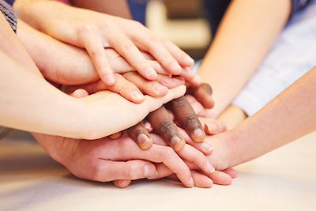

- You own and operate a charity
- Your goal is to invest money to improve educational outcomes for minority students, mainly African-American and Hispanic
- You want to do this primarily via scholarships and investing in school-specific programs
- You have tasked us with determining the schools whose minority students need the help most

## Process | Let’s talk about us

- To accomplish this, we look to the College Scorecard data
- Data provided on every institution in America by the US Department of Education
- Attempt to find schools that are not graduating as many minority students as they should be
- These schools are good candidates for financial intervention

[figure not shown]

## Data

- Original raw data file has over 1700 categories of information for each school (variables)…
- … and over 7,700 individual schools (rows), resulting in an unmanageably gigantic dataset
- we extracted just the 27 variables we used to produce the information in this report

## Data Continued

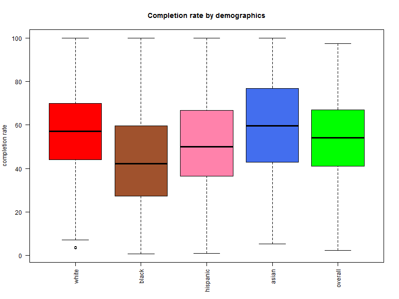

## Methodology

- We created two different models to predict a school’s black and hispanic graduation rates from other variables in the dataset: OLS and Ridge
- We trained the models using previous years data, and tested them on the current year
- We found that Ridge vastly outperformed OLS, so we used that for our report

| **Group** | **OLS MSE** | **Ridge MSE** |
| --- | --- | --- |
| **Black** | $1.129$ | $0.453$ |
| **Hispanic** | $1.038$ | $0.432$ |

## Analysis

- Compared predicted graduation rates to actual
- Ordered list with largest negative difference first
- This creates ranking of schools most underperforming expectations
- Restricted results to only “selective” or “highly selective” four-year institutions

## Results | Top 8 Most Underperforming Schools for Black Students

| School | Overall Grad Rate | Black Grad Rate |
| --- | --- | --- |
| Asbury University | 0.66 | 0.14 |
| Valparaiso University | 0.69 | 0.22 |
| Union University | 0.65 | 0.23 |
| Austin College | 0.74 | 0.33 |
| Wittenberg University | 0.66 | 0.22 |
| Rockhurst University | 0.69 | 0.35 |
| Kansas State University | 0.59 | 0.24 |
| Assumption College | 0.72 | 0.36 |

## Results | Top 8 Most Underperforming Schools for Hispanic Students

| School | Overall Grad Rate | Hispanic Grad Rate |
| --- | --- | --- |
| Albion College | 0.73 | 0.00 |
| Milligan College | 0.55 | 0.17 |
| Wabash College | 0.71 | 0.36 |
| Elizabethtown College | 0.73 | 0.38 |
| Calvin College | 0.73 | 0.46 |
| Oklahoma Christian University | 0.48 | 0.26 |
| University of Missouri-Kansas City | 0.52 | 0.31 |
| Westminster College | 0.68 | 0.43 |

## Results | Special Criteria

- For each minority group, we found the 100 most underperforming schools
- Of those schools, we organized them by the most appealing targets for funding based on a few special criteria
- Meant to highlight certain schools where funding will be stretched further, or the students assisted better positioned upon graduation

## Results | Underperforming Schools with Lowest Cost of Attendance (Black)

| School Name | Net Cost |
| --- | --- |
| Arizona State University-Tempe | 10858 |
| The University of Texas at Dallas | 12050 |
| San Diego State University | 12567 |
| University of North Carolina School of the Arts | 13625 |
| University of Illinois at Chicago | 13811 |
| Harvard University | 14068 |
| University of Arkansas | 14143 |
| Indiana University-Bloomington | 14370 |

## Results | Underperforming Schools with Lowest Cost of Attendance (Hispanic)

| School Name | Net Cost |
| --- | --- |
| University of Wyoming | 11603 |
| San Diego State University | 12567 |
| Stony Brook University | 13519 |
| University of North Carolina School of the Arts | 13625 |
| University of California-San Diego | 14136 |
| University of Louisville | 14370 |
| Purdue University-Main Campus | 14797 |
| University of Vermont | 15838 |

## Results | Underperforming Schools with Lowest Median Debt (Black)

| School Name | Median Post-Grad Debt |
| --- | --- |
| Duke University | 7000.00 |
| Harvard University | 7536.00 |
| Florida Institute of Technology | 9375.00 |
| Cornell University | 11500.00 |
| Vanderbilt University | 12000.00 |
| Embry-Riddle Aeronautical University-Daytona Beach | 13000.00 |
| Yale University | 13206.00 |
| San Diego State University | 13997.00 |

## Results | Underperforming Schools with Lowest Median Debt (Hispanic)

| School Name | Median Post-Grad Debt |
| --- | --- |
| Florida Institute of Technology | 9375.00 |
| Cornell University | 11500.00 |
| University of Wyoming | 12000.00 |
| University of Louisville | 12571.00 |
| Warren Wilson College | 12750.00 |
| University of Chicago | 12955.00 |
| Embry-Riddle Aeronautical University-Daytona Beach | 13000.00 |
| Embry-Riddle Aeronautical University-Prescott | 13000.00 |

## Conclusion

- The Previous lists of schools represent institutions not doing as well as expected when it comes to graduating their minority students
- Any one of which would be a good place to invest money, as their students clearly need support
- Depending on your organizations goals and financial capability, might be worth looking into schools where scholarships cost less or more fully support their students

## Problems Encountered

- Problems mostly revolve around lack of demographic data from College Scorecard
- Despite 1700+ variables, basically only two that had to do with race: graduation rates and school population proportion
- Would be much more helpful to have debt, scholarships, admission rates, retention rates, and more broken up by demographic
- Something important for USDE to look into as improving educational opportunities to minorities is incredibly important to creating a more just world

# Thank You | From Stacy, JD, Phil, and Tim!